# HBO Game of Thrones Analysis

#### Season 5 Episode 2

```python
#gathering the reviews from all pages of reviews for the first episode

web = "https://www.rottentomatoes.com/tv/game-of-thrones/s05/e02/reviews/?page="
webview = "&sort="

alldata = []

for page in range(1,10):
    url = web + str(page) + webview
    data = html.fromstring(requests.get(url).text)



    for i in data.xpath("//tr"):
        review = i.xpath("td[5]/p/text()")

        Fivedata.append(review)
```

```python
len(Fivedata)
```

```
131
```

#### Season 5 Episode 3

```python
#gathering the reviews from all pages of reviews for the first episode

web = "https://www.rottentomatoes.com/tv/game-of-thrones/s05/e03/reviews/?page="
webview = "&sort="

alldata = []

for page in range(1,10):
    url = web + str(page) + webview
    data = html.fromstring(requests.get(url).text)



    for i in data.xpath("//tr"):
        review = i.xpath("td[5]/p/text()")

        Fivedata.append(review)
```

```python
len(Fivedata)
```

```
198
```

#### Season 5 Episode 4

```python
#gathering the reviews from all pages of reviews for the first episode

web = "https://www.rottentomatoes.com/tv/game-of-thrones/s05/e04/reviews/?page="
webview = "&sort="

alldata = []

for page in range(1,10):
    url = web + str(page) + webview
    data = html.fromstring(requests.get(url).text)



    for i in data.xpath("//tr"):
        review = i.xpath("td[5]/p/text()")

        Fivedata.append(review)
```

```python
len(Fivedata)
```

```
268
```

#### Season 5 Episode 5

```python
#gathering the reviews from all pages of reviews for the first episode

web = "https://www.rottentomatoes.com/tv/game-of-thrones/s05/e05/reviews/?page="
webview = "&sort="

alldata = []

for page in range(1,10):
    url = web + str(page) + webview
    data = html.fromstring(requests.get(url).text)



    for i in data.xpath("//tr"):
        review = i.xpath("td[5]/p/text()")

        Fivedata.append(review)
```

```python
len(Fivedata)
```

```
334
```

#### Season 5 Episode 6

```python
#gathering the reviews from all pages of reviews for the first episode

web = "https://www.rottentomatoes.com/tv/game-of-thrones/s05/e06/reviews/?page="
webview = "&sort="

alldata = []

for page in range(1,10):
    url = web + str(page) + webview
    data = html.fromstring(requests.get(url).text)



    for i in data.xpath("//tr"):
        review = i.xpath("td[5]/p/text()")

        Fivedata.append(review)
```

```python
len(Fivedata)
```

```
402
```

#### Season 5 Episode 7

```python
#gathering the reviews from all pages of reviews for the first episode

web = "https://www.rottentomatoes.com/tv/game-of-thrones/s05/e07/reviews/?page="
webview = "&sort="

alldata = []

for page in range(1,10):
    url = web + str(page) + webview
    data = html.fromstring(requests.get(url).text)



    for i in data.xpath("//tr"):
        review = i.xpath("td[5]/p/text()")

        Fivedata.append(review)
```

```python
len(Fivedata)
```

```
468
```

#### Season 5 Episode 8

```python
#gathering the reviews from all pages of reviews for the first episode

web = "https://www.rottentomatoes.com/tv/game-of-thrones/s05/e08/reviews/?page="
webview = "&sort="

alldata = []

for page in range(1,10):
    url = web + str(page) + webview
    data = html.fromstring(requests.get(url).text)



    for i in data.xpath("//tr"):
        review = i.xpath("td[5]/p/text()")

        Fivedata.append(review)
```

```python
len(Fivedata)
```

```
536
```

#### Season 5 Episode 9

```python
#gathering the reviews from all pages of reviews for the first episode

web = "https://www.rottentomatoes.com/tv/game-of-thrones/s05/e09/reviews/?page="
webview = "&sort="

alldata = []

for page in range(1,10):
    url = web + str(page) + webview
    data = html.fromstring(requests.get(url).text)



    for i in data.xpath("//tr"):
        review = i.xpath("td[5]/p/text()")

        Fivedata.append(review)
```

```python
len(Fivedata)
```

```
606
```

#### Season 5 Episode 10

```python
#gathering the reviews from all pages of reviews for the first episode

web = "https://www.rottentomatoes.com/tv/game-of-thrones/s05/e10/reviews/?page="
webview = "&sort="

alldata = []

for page in range(1,10):
    url = web + str(page) + webview
    data = html.fromstring(requests.get(url).text)



    for i in data.xpath("//tr"):
        review = i.xpath("td[5]/p/text()")

        Fivedata.append(review)
```

```python
len(Fivedata)
```

```
674
```

```python
df5 = pd.DataFrame(Fivedata)
df5.columns = ['review']
df5.head()
```

|  | review |
| --- | --- |
| 0 | None |
| 1 | None |
| 2 | Through the action at Castle Black, "The Wars ... |
| 3 | This episode shows something very different - ... |
| 4 | While it contemplates the kind of leadership i... |

## Rotten Tomatoes Business and Data Understanding

### This data is all text data retrieved from Rotten Tomatoes. The authors of these reviews all work for a big publication company of some sort and are familiar with the show. We are assuming that they have seen all of the seasons leading up to season 8, as most people have. What we are trying to see here is how this season compares to that of season 5. Season 5 is a very important season because after season 5, the writers of the TV show will not have any source material to go off of. The author of the Game of Thrones books has not finished the series, leaving the writers of the show to create their own plots, subplots, and ultimate endings. In this analysis we are only collecting the review data. There is not enough ratings on the show to make it worth while to scrape, we also do not need to know who is writing about the show. Since our goal is to see how the show is being perceived, we only care about the reviews!

## Data Cleaning and Preparation

### Since we only have review data in a text format, we can drop our reviews that do not have any text. I am not sure how this happened, if it is a problem with our xpath, but this is simple to do and then we should be ready to go!

```python
# Here we see that we have 72 reviews with no text data!
df8.isnull().sum()
```

```
review    72
dtype: int64
```

```python
df8 = df8.dropna(subset=['review'])
```

```python
#Problem Solved!
df8.isnull().sum()
```

```
review    0
dtype: int64
```

```python
# We have a whopping 180 blank reviews from season 5!
df5.isnull().sum()
```

```
review    180
dtype: int64
```

```python
df5 = df5.dropna(subset=['review'])
```

```python
df5.isnull().sum()
```

```
review    0
dtype: int64
```

## Descriptive Analysis

```python
#Creating CSV of Season 8
df8.to_csv("data/df8.csv", index=False, encoding='utf-8')
```

```
(-0.5, 399.5, 199.5, -0.5)
```

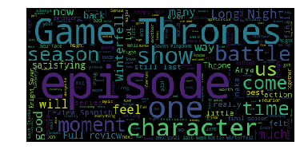

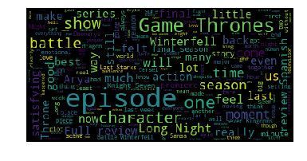

```python
# Word Cloud
from os import path
from wordcloud import WordCloud
import matplotlib.pyplot as plt
%matplotlib inline

# Read the whole text.
text = open('data/df8.csv').read()

# Generate a word cloud image
wordcloud = WordCloud().generate(text)

# Display the generated image:
# the matplotlib way:
plt.imshow(wordcloud)
plt.axis("off")

# take relative word frequencies into account, lower max_font_size
wordcloud = WordCloud(max_font_size=40, relative_scaling=.5).generate(text)
plt.figure()
plt.imshow(wordcloud)
plt.axis("off")
```

### Above, words such as; satisfying, battle, good, long night, feel, and best stick out to me!

```python
# Creating a CSV of Season 5
df5.to_csv("data/df5.csv", index=False, encoding='utf-8')
```

```
(-0.5, 399.5, 199.5, -0.5)
```

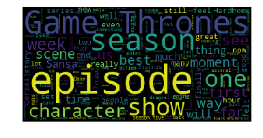

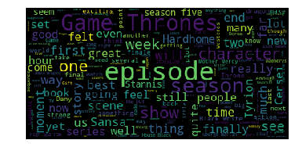

```python
#WordCloud
%matplotlib inline

# Read the whole text.
text = open('data/df5.csv').read()

# Generate a word cloud image
wordcloud = WordCloud().generate(text)

# Display the generated image:
# the matplotlib way:
plt.imshow(wordcloud)
plt.axis("off")

# take relative word frequencies into account, lower max_font_size
wordcloud = WordCloud(max_font_size=40, relative_scaling=.5).generate(text)
plt.figure()
plt.imshow(wordcloud)
plt.axis("off")
```

### Above, words such as; best, Tyrion, great, Sansa, Cersei, Dany, and Stanis are the words that stick out to me the most. It looks like season 5 has reviews that are more focused on the characters, where season 8 is more focused on the show as a whole.

```python
# import packages
# import nltk (natural language tool kit), a popular python package for text mining
import nltk
# stopwords, FreqDist, word_tokenize
from nltk.corpus import stopwords
from nltk import FreqDist, word_tokenize
from nltk.stem.porter import PorterStemmer
from nltk.stem import WordNetLemmatizer
from nltk.corpus import stopwords
#regular expression
import re
#csv
import csv
# Excel-like format
import pandas as pd
#data visualization
import matplotlib.pyplot as plt
%matplotlib inline
```

```python
df5_d = []
openfile = open('data/df5.csv', 'r')
r = csv.reader(openfile)
for i in r:
# get the first column only (ignoring the second column)
    df5_d.append(i)
openfile.close()

print(len(df5_d))
```

```
495
```

```python
#Peeking the data
for i in df5_d[:5]:
    print(i)
```

```
['review']
['Through the action at Castle Black, "The Wars to Come" demonstrates the value the show is getting by letting different worlds collide.']
['This episode shows something very different - war is coming, in many different places and taking many different shapes. ']
['While it contemplates the kind of leadership it will next put onscreen, the leadership behind the scenes at Game Of Thrones looks refreshingly willing to roll with the punches.']
["Directed by the great Michael Slovis - the man responsible for making several of this generation's best shows look as good as they do - this is emphatically a set-up episode."]
```

```python
# text preprocessing
tokens = str(df5_d)
#lowecases
tokens = tokens.lower()
# Remove useless numbers and alphanumerical words
tokens = re.sub("[^a-zA-Z0-9]", " ", tokens)
#tokenization or word split
tokens = word_tokenize(tokens)
#get stemming words or lemmas
wordnet_lemmatizer = WordNetLemmatizer()
tokens = (wordnet_lemmatizer.lemmatize(word) for word in tokens)
#additional stopwrods
more_stopwords = set(('episode', 'throne', 'game', 'season', 'show', 'week', 'see', 'way', 'scene'))
extra_stoplist = set(stopwords.words('english')) | more_stopwords
tokens = (word for word in tokens if word not in extra_stoplist)
# Filter non-alphanumeric characters from tokens
tokens = (word for word in tokens if word.isalpha())
#remove short words
tokens = (word for word in tokens if len(word) >= 3)
```

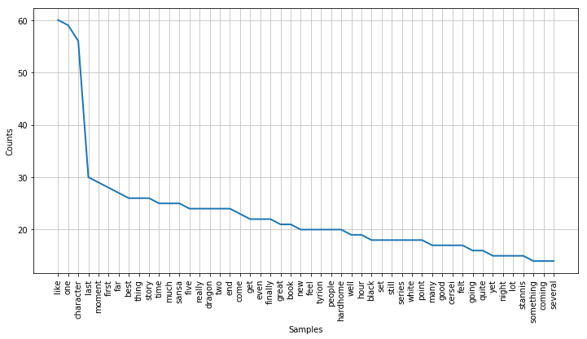

```python
# Season 5 Word frequency

df5_dist = nltk.FreqDist(tokens)
df5_dist

plt.figure(figsize=(12,6))
df5_dist.plot(50)
```

```python
#Season 8 CSV
df8_d = []
openfile = open('data/df8.csv', 'r')
r = csv.reader(openfile)
for i in r:
# get the first column only (ignoring the second column)
    df8_d.append(i)
openfile.close()

print(len(df8_d))
```

```
383
```

```python
# text preprocessing
tokens = str(df8_d)
#lowecases
tokens = tokens.lower()
# Remove useless numbers and alphanumerical words
tokens = re.sub("[^a-zA-Z0-9]", " ", tokens)
#tokenization or word split
tokens = word_tokenize(tokens)
#get stemming words or lemmas
wordnet_lemmatizer = WordNetLemmatizer()
tokens = (wordnet_lemmatizer.lemmatize(word) for word in tokens)
#additional stopwrods
more_stopwords = set(('episode', 'throne', 'game', 'season', 'show'))
extra_stoplist = set(stopwords.words('english')) | more_stopwords
tokens = (word for word in tokens if word not in extra_stoplist)
# Filter non-alphanumeric characters from tokens
tokens = (word for word in tokens if word.isalpha())
#remove short words
tokens = (word for word in tokens if len(word) >= 3)
```

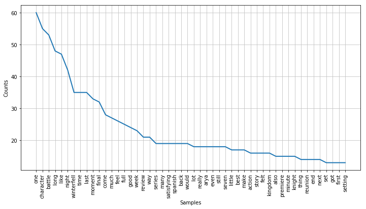

```python
# Season 8 Word frequency analysis

df8_dist = nltk.FreqDist(tokens)
df8_dist

plt.figure(figsize=(12,6))
df8_dist.plot(50)
```